# R and GIS, or R as GIS: handling spatial data: Representation and visualisation of spatial data

Roger Bivand

Tuesday, 27 August 2019, 09:00-10:40; Wolfson Medical School building Gannochy room

### Copyright

All the material presented here, to the extent it is original, is available under [CC-BY-SA](https://creativecommons.org/licenses/by-sa/4.0/). Parts build on joint tutorials with Edzer Pebesma.

## Session I

- 09:00-09:30 (20+10) Vector representation: **sf** replaces **sp**, **rgeos** and **rgdal**: vector
- 09:30-10:00 (20+10) Raster representation: **stars**/**sf** replace **sp** and **rgdal**: **raster** remains for now
- 10:00-10:40 (20+20) Visualization: **tmap**, **cartography**, **ggplot2** and **mapview**

## Outline

- Spatial and spatio-temporal data are characterised by structures that distinguish them from typical tabular data
- The geometric structures also have spatial reference system information, and can adhere to standards, which may ease geometrical operations
- Satellite data and numerical model output data typically have regular grid structures, but these are often domain-specific
- Computationally intensive tasks include interpolation, upsampling, focal operations, change of support and handling vector data with very detailed boundaries, as well as modelling using Bayesian inference

## A short history of handling spatial data in R

- pre-2003: several people doing spatial statistics or map manipulation with S-Plus (1996 SpatialStats module), and later R (e.g. spatial in MASS; spatstat, maptools, geoR, splancs, gstat, …)
- 2003: workshop at [DSC](https://www.r-project.org/conferences/DSC-2003/), concensus that a package with base classes should be useful; this ended up being a multiplicator
- 2003: start of r-sig-geo
- 2003: rgdal released on CRAN (with GDAL and PROJ support)
- 2005: sp released on CRAN; **sp** support in **rgdal**
- 2008: [Applied Spatial Data Analysis with R](https://www.asdar-book.org/)
- 2011: rgeos released on CRAN (with GEOS support for **sp** class objects^)
- 2013: second edition of [Applied Spatial Data Analysis with R](https://www.asdar-book.org/) (Bivand, Pebesma, and Gomez-Rubio 2013)
- 2015 [JSS special issue](https://www.jstatsoft.org/index.php/jss/issue/view/v063)
- 2016-7: **sf** [simple features for R](https://cran.r-project.org/package=sf), R consortium support (combines GDAL, GEOS and PROJ support and S3 classes)
- 2017-9: **stars** [spatiotemporal tidy arrays for R](https://cran.r-project.org/package=stars), R consortium support (considered pretty much “finished”; uses **sf** to interface GDAL)
- 2019 [Geocomputation with R](https://geocompr.robinlovelace.net/) (Lovelace, Nowosad, and Muenchow 2019)
- 2020 [Spatial Data Science; uses cases in R](https://r-spatial.org/book) (Pebesma and Bivand, n.d.)

## Spatial data

Spatial data typically combine position data in 2D (or 3D), attribute data and metadata related to the position data. Much spatial data could be called map data or GIS data. We collect and handle much more position data since global navigation satellite system (GNSS) like GPS came on stream 20 years ago, earth observation satellites have been providing data for longer.

Lapa et al. (2001) (Leprosy surveillance in Olinda, Brazil, using spatial analysis techniques) made available the underlying data set of Olinda census tracts (setor) in the Corrego Alegre 1970-72 / UTM zone 25S projection (EPSG:22525).

```r
library(sf)
olinda <- st_read("data/olinda.gpkg")
st_crs(olinda) <- 22525
```

```r
library(mapview)
mapview(olinda)
```

## Vector data

```r
all(st_is(olinda, "XY"))
```

```
## [1] TRUE
```

```r
str(st_coordinates(st_geometry(olinda)[[1]]))
```

```
##  num [1:13, 1:4] 295638 295599 295506 295599 295560 ...
##  - attr(*, "dimnames")=List of 2
##   ..$ : NULL
##   ..$ : chr [1:4] "X" "Y" "L1" "L2"
```

### Representing spatial vector data in R (**sp**)

```r
library(sp)
str(slot(as(st_geometry(olinda), "Spatial"), "polygons")[[1]])
```

```
## Formal class 'Polygons' [package "sp"] with 5 slots
##   ..@ Polygons :List of 1
##   .. ..$ :Formal class 'Polygon' [package "sp"] with 5 slots
##   .. .. .. ..@ labpt  : num [1:2] 295460 9120358
##   .. .. .. ..@ area   : num 79139
##   .. .. .. ..@ hole   : logi FALSE
##   .. .. .. ..@ ringDir: int 1
##   .. .. .. ..@ coords : num [1:13, 1:2] 295638 295599 295506 295599 295560 ...
##   ..@ plotOrder: int 1
##   ..@ labpt    : num [1:2] 295460 9120358
##   ..@ ID       : chr "ID1"
##   ..@ area     : num 79139
```

### Representing spatial vector data in R (**sf**)

The recent **sf** package bundles GDAL and GEOS (**sp** just defined the classes and methods, leaving I/O and computational geometry to other packages). **sf** used `data.frame` objects with one (or more) geometry column for vector data. The representation follows ISO 19125 (*Simple Features*), and has WKT (text) and WKB (binary) representations (used by GDAL and GEOS internally). The drivers include PostGIS and other database constructions permitting selection, and WFS for server APIs (**rgdal** does too, but requires more from the user).

```r
strwrap(st_as_text(st_geometry(olinda)[[1]]))
```

```
## [1] "POLYGON ((295637.8 9120506, 295598.5 9120446, 295505.7 9120324,"
## [2] "295599.4 9120260, 295560.2 9120190, 295519.9 9120125, 295313.9"
## [3] "9120294, 295331 9120477, 295352.3 9120494, 295386.4 9120520,"
## [4] "295420.5 9120528, 295637.8 9120507, 295637.8 9120506))"
```

### Simple feature access in R: package `sf`

- Simple feature access is an [ISO standard](http://www.opengeospatial.org/standards/sfa) that is widely adopted. It is used in spatial databases, GIS, open source libraries, GeoJSON, GeoSPARQL, etc.

**sf** uses the OSGEO stack of software:

```r
sf_extSoftVersion()
```

```
##           GEOS           GDAL         proj.4 GDAL_with_GEOS
##        "3.7.2"        "3.0.1"        "6.1.1"         "true"
```

Package **sf** provides handling of feature data, where feature geometries are points, lines, polygons or combinations of those. It implements the full set of geometric functions described in the *simple feature access* standard, and some. The basic storage is very simple, and uses only base R types (list, matrix).

- feature sets are held as records (rows) in `"sf"` objects, inheriting from `"data.frame"`
- `"sf"` objects have at least one simple feature geometry list-column of class `"sfc"`
- geometry list-columns are *sticky*, that is they stay stuck to the object when subsetting columns, for example using `[`
- `"sfc"` geometry list-columns have a bounding box and a coordinate reference system as attribute, and a class attribute pointing out the common type (or `"GEOMETRY"` in case of a mix)
- a single simple feature geometry is of class `"sfg"`, and further classes pointing out dimension and type

Storage of simple feature geometry:

- `"POINT"` is a numeric vector
- `"LINESTRING"` and `"MULTIPOINT"` are numeric matrix, points/vertices in rows
- `"POLYGON"` and `"MULTILINESTRING"` are lists of matrices
- `"MULTIPOLYGON"` is a lists of those
- `"GEOMETRYCOLLECTION"` is a list of typed geometries

To build from scratch:

```r
p1 = st_point(c(3,5))
class(p1)
```

```
## [1] "XY"    "POINT" "sfg"
```

```r
p2 = st_point(c(4,6))
p3 = st_point(c(4,4))
pts = st_sfc(p1, p2, p3)
class(pts)
```

```
## [1] "sfc_POINT" "sfc"
```

```r
sf = st_sf(a = c(3,2.5,4), b = c(1,2,4), geom = pts)
class(sf)
```

```
## [1] "sf"         "data.frame"
```

```r
sf
```

```
## Simple feature collection with 3 features and 2 fields
## geometry type:  POINT
## dimension:      XY
## bbox:           xmin: 3 ymin: 4 xmax: 4 ymax: 6
## epsg (SRID):    NA
## proj4string:    NA
##     a b        geom
## 1 3.0 1 POINT (3 5)
## 2 2.5 2 POINT (4 6)
## 3 4.0 4 POINT (4 4)
```

### Input/output

```r
library(osmdata)
bbox <- opq(bbox = 'olinda brazil')
(osm_water <- osmdata_sf(add_osm_feature(bbox, key = 'natural', value = 'water'))$osm_points)
```

```
## Request failed [504]. Retrying in 1 seconds...
```

```
## Simple feature collection with 2132 features and 4 fields
## geometry type:  POINT
## dimension:      XY
## bbox:           xmin: -34.96294 ymin: -8.067045 xmax: -34.82622 ymax: -7.954524
## epsg (SRID):    4326
## proj4string:    +proj=longlat +datum=WGS84 +no_defs
## First 10 features:
##           amenity ferry natural public_transport
## 100179100    <NA>  <NA>    <NA>             <NA>
## 100179257    <NA>  <NA>    <NA>             <NA>
## 100179264    <NA>  <NA>    <NA>             <NA>
## 100179540    <NA>  <NA>    <NA>             <NA>
## 100179822    <NA>  <NA>    <NA>             <NA>
## 100179837    <NA>  <NA>    <NA>             <NA>
## 100180114    <NA>  <NA>    <NA>             <NA>
## 100180313    <NA>  <NA>    <NA>             <NA>
## 100180653    <NA>  <NA>    <NA>             <NA>
## 100180925    <NA>  <NA>    <NA>             <NA>
##                              geometry
## 100179100 POINT (-34.90247 -8.057249)
## 100179257 POINT (-34.90022 -8.059983)
## 100179264 POINT (-34.89981 -8.066445)
## 100179540 POINT (-34.90596 -8.038479)
## 100179822 POINT (-34.86795 -8.042321)
## 100179837 POINT (-34.92832 -8.030573)
## 100180114  POINT (-34.9038 -8.047111)
## 100180313  POINT (-34.8687 -8.043948)
## 100180653  POINT (-34.90751 -8.03756)
## 100180925 POINT (-34.92747 -8.031826)
```

We write in EPSG:31985, SIRGAS 2000 UTM zone 25S projected coordinates, rather than WGS84 geographical coordinates.

```r
tf <- tempfile(fileext=".gpkg")
st_write(st_transform(osm_water, 31985), dsn=tf, layer="water-pts", driver="GPKG")
```

```
## Writing layer `water-pts' to data source `/tmp/RtmpMd1Hv9/file2b13202a56e3.gpkg' using driver `GPKG'
## features:       2132
## fields:         4
## geometry type:  Point
```

```r
st_layers(tf)
```

```
## Driver: GPKG
## Available layers:
##   layer_name geometry_type features fields
## 1  water-pts         Point     2132      4
```

```r
water_pts <- st_read(tf)
```

Here we transformed to SIRGAS 2000 UTM zone 25S (EPSG:31985), to match Landsat raster dat to be used later.

```r
olinda_sirgas2000 <- st_transform(olinda, 31985)
st_crs(olinda_sirgas2000)
```

```
## Coordinate Reference System:
##   EPSG: 31985
##   proj4string: "+proj=utm +zone=25 +south +ellps=GRS80 +towgs84=0,0,0,0,0,0,0 +units=m +no_defs"
```

## Exercise + review

Try doing this in pairs or small groups and discuss what is going on.

Look at the [North Carolina SIDS data vignette](https://r-spatial.github.io/spdep/articles/sids.html) for background:

```r
library(sf)
nc <- st_read(system.file("shapes/sids.shp", package="spData")[1], quiet=TRUE)
st_crs(nc) <- "+proj=longlat +datum=NAD27"
row.names(nc) <- as.character(nc$FIPSNO)
head(nc)
```

```
## Simple feature collection with 6 features and 22 fields
## geometry type:  MULTIPOLYGON
## dimension:      XY
## bbox:           xmin: -81.74107 ymin: 36.07282 xmax: -75.77316 ymax: 36.58965
## epsg (SRID):    4267
## proj4string:    +proj=longlat +datum=NAD27 +no_defs
##       CNTY_ID  AREA PERIMETER CNTY_        NAME  FIPS FIPSNO CRESS_ID
## 37009    1825 0.114     1.442  1825        Ashe 37009  37009        5
## 37005    1827 0.061     1.231  1827   Alleghany 37005  37005        3
## 37171    1828 0.143     1.630  1828       Surry 37171  37171       86
## 37053    1831 0.070     2.968  1831   Currituck 37053  37053       27
## 37131    1832 0.153     2.206  1832 Northampton 37131  37131       66
## 37091    1833 0.097     1.670  1833    Hertford 37091  37091       46
##       BIR74 SID74 NWBIR74 BIR79 SID79 NWBIR79 east north      x       y
## 37009  1091     1      10  1364     0      19  164   176 -81.67 4052.29
## 37005   487     0      10   542     3      12  183   182 -50.06 4059.70
## 37171  3188     5     208  3616     6     260  204   174 -16.14 4043.76
## 37053   508     1     123   830     2     145  461   182 406.01 4035.10
## 37131  1421     9    1066  1606     3    1197  385   176 281.10 4029.75
## 37091  1452     7     954  1838     5    1237  411   176 323.77 4028.10
##             lon      lat L_id M_id                       geometry
## 37009 -81.48594 36.43940    1    2 MULTIPOLYGON (((-81.47276 3...
## 37005 -81.14061 36.52443    1    2 MULTIPOLYGON (((-81.23989 3...
## 37171 -80.75312 36.40033    1    2 MULTIPOLYGON (((-80.45634 3...
## 37053 -76.04892 36.45655    1    4 MULTIPOLYGON (((-76.00897 3...
## 37131 -77.44057 36.38799    1    4 MULTIPOLYGON (((-77.21767 3...
## 37091 -76.96474 36.38189    1    4 MULTIPOLYGON (((-76.74506 3...
```

The variables are largely count data, `L_id` and `M_id` are grouping variables. We can also read the original neighbour object:

```r
library(spdep)
gal_file <- system.file("weights/ncCR85.gal", package="spData")[1]
ncCR85 <- read.gal(gal_file, region.id=nc$FIPSNO)
ncCR85
```

```
## Neighbour list object:
## Number of regions: 100
## Number of nonzero links: 492
## Percentage nonzero weights: 4.92
## Average number of links: 4.92
```

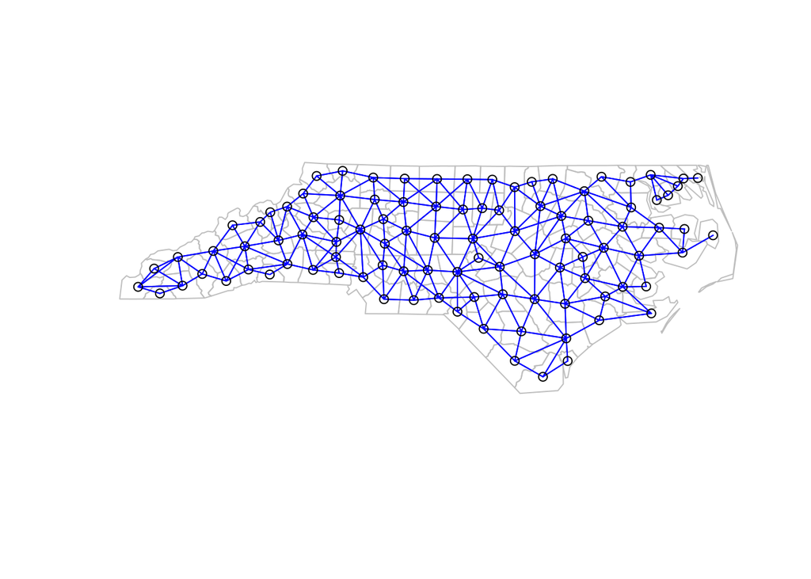

```r
plot(st_geometry(nc), border="grey")
plot(ncCR85, st_centroid(st_geometry(nc), of_largest_polygon), add=TRUE, col="blue")
```

Now generate a random variable. Here I’ve set the seed - maybe choose your own, and compare outcomes with the people around you. With many people in the room, about 5 in 100 may get a draw that is autocorrelated when tested with Moran’s $I$ (why?).

```r
set.seed(1)
nc$rand <- rnorm(nrow(nc))
lw <- nb2listw(ncCR85, style="B")
moran.test(nc$rand, listw=lw, alternative="two.sided")
```

```
##
##  Moran I test under randomisation
##
## data:  nc$rand
## weights: lw
##
## Moran I statistic standard deviate = -0.82038, p-value = 0.412
## alternative hypothesis: two.sided
## sample estimates:
## Moran I statistic       Expectation          Variance
##      -0.060754158      -0.010101010       0.003812269
```

Now we’ll create a trend (maybe try plotting `LM` to see the trend pattern). Do we get different test outcomes by varying beta and sigma (alpha is constant).

```r
nc$LM <- as.numeric(interaction(nc$L_id, nc$M_id))
alpha <- 1
beta <- 0.5
sigma <- 2
nc$trend <- alpha + beta*nc$LM + sigma*nc$rand
moran.test(nc$trend, listw=lw, alternative="two.sided")
```

```
##
##  Moran I test under randomisation
##
## data:  nc$trend
## weights: lw
##
## Moran I statistic standard deviate = 6.1163, p-value = 9.58e-10
## alternative hypothesis: two.sided
## sample estimates:
## Moran I statistic       Expectation          Variance
##       0.368410659      -0.010101010       0.003829901
```

To get back to reality, include the trend in a linear model, and test again.

```r
lm.morantest(lm(trend ~ LM, nc), listw=lw, alternative="two.sided")
```

```
##
##  Global Moran I for regression residuals
##
## data:
## model: lm(formula = trend ~ LM, data = nc)
## weights: lw
##
## Moran I statistic standard deviate = -0.50788, p-value = 0.6115
## alternative hypothesis: two.sided
## sample estimates:
## Observed Moran I      Expectation         Variance
##     -0.049567147     -0.018718176      0.003689356
```

So we can manipulate a missing variable mis-specification to look like spatial autocorrelation. Is this informative?

#### Extra problem (own time after we’re done if you like):

Sometimes we only have data on a covariate for aggregates of our units of observation. What happens when we “copy out” these aggregate values to the less aggregated observations? First we’ll aggregate `nc` by `LM`, then make a neighbour object for the aggregate units

```r
aggLM <- aggregate(nc[,"LM"], list(nc$LM), head, n=1)
(aggnb <- poly2nb(aggLM))
```

```
## Neighbour list object:
## Number of regions: 12
## Number of nonzero links: 46
## Percentage nonzero weights: 31.94444
## Average number of links: 3.833333
```

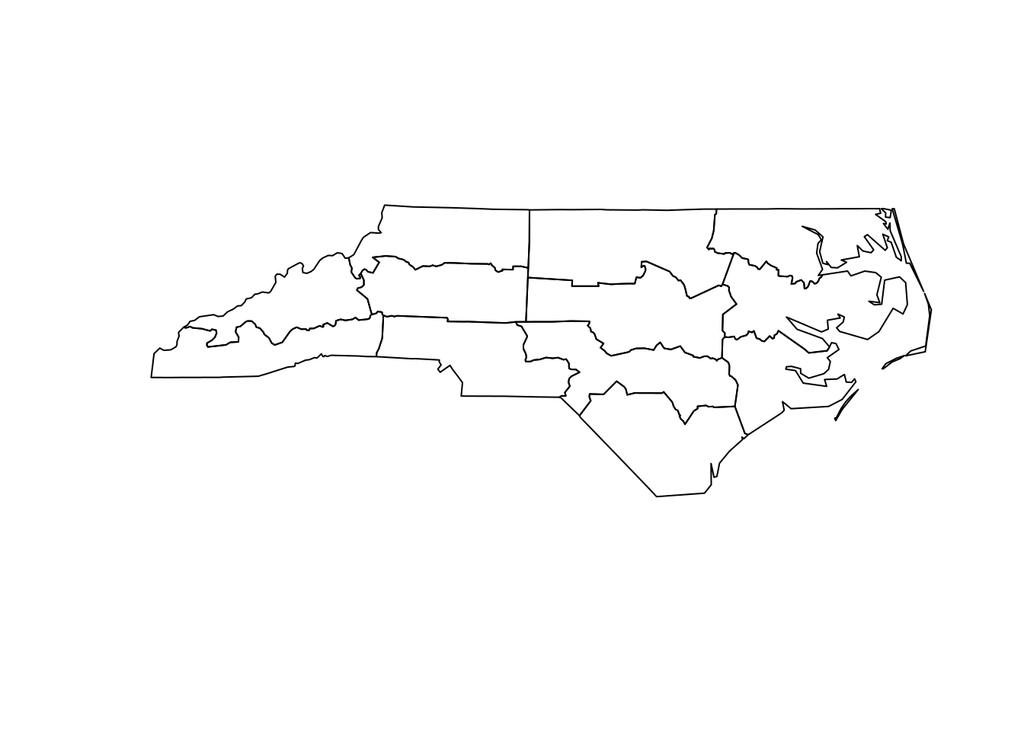

```r
plot(st_geometry(aggLM))
```

Next, draw a random sample for the aggregated units:

```r
set.seed(1)
LMrand <- rnorm(nrow(aggLM))
```

Check that it does not show any spatial autocorrelation:

```r
moran.test(LMrand, nb2listw(aggnb, style="B"))
```

```
##
##  Moran I test under randomisation
##
## data:  LMrand
## weights: nb2listw(aggnb, style = "B")
##
## Moran I statistic standard deviate = -0.24911, p-value = 0.5984
## alternative hypothesis: greater
## sample estimates:
## Moran I statistic       Expectation          Variance
##       -0.13101880       -0.09090909        0.02592483
```

Copy it out to the full data set, indexing on values of LM; the pattern now looks pretty autocorrelated

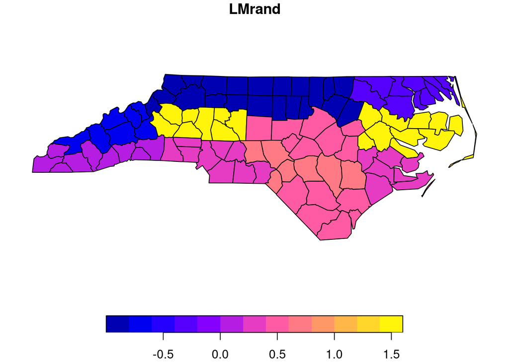

```r
nc$LMrand <- LMrand[match(nc$LM, aggLM$LM)]
plot(nc[,"LMrand"])
```

which it is:

```r
moran.test(nc$LMrand, listw=lw, alternative="two.sided")
```

```
##
##  Moran I test under randomisation
##
## data:  nc$LMrand
## weights: lw
##
## Moran I statistic standard deviate = 9.4301, p-value < 2.2e-16
## alternative hypothesis: two.sided
## sample estimates:
## Moran I statistic       Expectation          Variance
##       0.575091242      -0.010101010       0.003850884
```

We’ve manipulated ourselves into a situation with abundant spatial autocorrelation at the level of the counties, but only by copying out from a more aggregated level. What is going on?

## Raster data

Spatial raster data is observed using rectangular (often square) cells, within which attribute data are observed. Raster data are very rarely object-based, very often they are field-based and could have been observed everywhere. We probably do not know where within the raster cell the observed value is correct; all we know is that at the chosen resolution, this is the value representing the whole cell area.

```r
library(elevatr)
```

```r
elevation <- get_elev_raster(as(olinda_sirgas2000, "Spatial"), z = 14)
```

```
## Merging DEMs
```

```
## Reprojecting DEM to original projection
```

```
## Note: Elevation units are in meters.
## Note: The coordinate reference system is:
##  +proj=utm +zone=25 +south +ellps=GRS80 +towgs84=0,0,0,0,0,0,0 +units=m +no_defs
```

```r
elevation[elevation$layer < 1] <- NA
```

```r
mapview(elevation, col=terrain.colors)
```

### Representing spatial raster data in R (**sp** and **raster**)

The **raster** package S4 representation builds on the **sp** representation, using a `GridTopology` S4 object to specify the grid, and a data frame to hold the data. **raster** defines `RasterLayer`, and combinations of layers as stacks (may be different storage classes) or bricks (same storage class - array). Adding time remains an issue; **raster** can avoid reading data into memory using **rgdal** mechanisms.

```r
elevation
```

```
## class      : RasterLayer
## dimensions : 3096, 3097, 9588312  (nrow, ncol, ncell)
## resolution : 4.73, 4.7  (x, y)
## extent     : 286508, 301156.8, 9106220, 9120771  (xmin, xmax, ymin, ymax)
## crs        : +proj=utm +zone=25 +south +ellps=GRS80 +towgs84=0,0,0,0,0,0,0 +units=m +no_defs
## source     : memory
## names      : layer
## values     : 1, 93  (min, max)
```

```r
sp::gridparameters(as(elevation, "SpatialGrid"))
```

```
##    cellcentre.offset cellsize cells.dim
## s1          286510.4     4.73      3097
## s2         9106222.6     4.70      3096
```

```r
library(stars)
e1 <- st_as_stars(elevation)
e1
```

```
## stars object with 2 dimensions and 1 attribute
## attribute(s), summary of first 1e+05 cells:
##      layer
##  Min.   : 1.00
##  1st Qu.: 8.00
##  Median :21.04
##  Mean   :25.04
##  3rd Qu.:37.50
##  Max.   :85.50
##  NA's   :50010
## dimension(s):
##   from   to  offset delta                       refsys point values
## x    1 3097  286508  4.73 +proj=utm +zone=25 +south...    NA   NULL [x]
## y    1 3096 9120771  -4.7 +proj=utm +zone=25 +south...    NA   NULL [y]
```

### Analysing raster data

Package [`raster`](https://rspatial.org/raster/index.html) has been around for a long time, is robust, well tested, versatile, and works for large rasters. We will not discuss it here.

The more recent [`stars`](https://r-spatial.github.io/stars/) package has a different take on raster data, and will be used here. The following example loads 6 bands from a (section of a) Landsat 7 image, and plots it:

```r
fn <- system.file("tif/L7_ETMs.tif", package = "stars")
system.time(L7 <- read_stars(fn))
```

```
##    user  system elapsed
##   0.015   0.001   0.016
```

```r
L7
```

```
## stars object with 3 dimensions and 1 attribute
## attribute(s):
##   L7_ETMs.tif
##  Min.   :  1.00
##  1st Qu.: 54.00
##  Median : 69.00
##  Mean   : 68.91
##  3rd Qu.: 86.00
##  Max.   :255.00
## dimension(s):
##      from  to  offset delta                       refsys point values
## x       1 349  288776  28.5 +proj=utm +zone=25 +south... FALSE   NULL [x]
## y       1 352 9120761 -28.5 +proj=utm +zone=25 +south... FALSE   NULL [y]
## band    1   6      NA    NA                           NA    NA   NULL
```

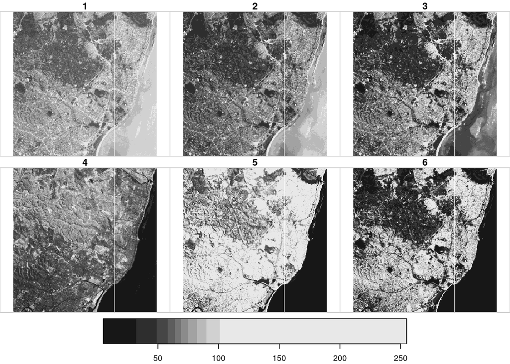

```r
plot(L7)
```

The irregular color breaks come from the default of using “type = quantile” to `classInt::classIntervals()`, which causes [histogram stretching](https://en.wikipedia.org/wiki/Histogram_equalization); this is done over all 6 bands.

We can compute an index like [ndvi](https://en.wikipedia.org/wiki/Normalized_difference_vegetation_index), and plot it:

```r
ndvi <- function(x) (x[4] - x[3])/(x[4] + x[3])
(s2.ndvi <- st_apply(L7, c("x", "y"), ndvi))
```

```
## stars object with 2 dimensions and 1 attribute
## attribute(s):
##      ndvi
##  Min.   :-0.75342
##  1st Qu.:-0.20301
##  Median :-0.06870
##  Mean   :-0.06432
##  3rd Qu.: 0.18667
##  Max.   : 0.58667
## dimension(s):
##   from  to  offset delta                       refsys point values
## x    1 349  288776  28.5 +proj=utm +zone=25 +south... FALSE   NULL [x]
## y    1 352 9120761 -28.5 +proj=utm +zone=25 +south... FALSE   NULL [y]
```

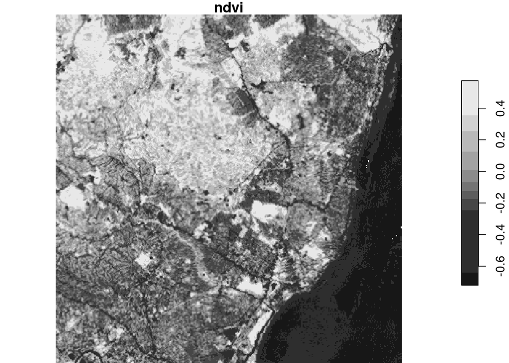

```
##    user  system elapsed
##   0.097   0.000   0.097
```

```r
system.time(plot(s2.ndvi))
```

### stars: out-of-memory

```r
system.time(L7 <- read_stars(fn, proxy=TRUE))
```

```
##    user  system elapsed
##   0.003   0.000   0.003
```

```r
L7
```

```
## stars_proxy object with 1 attribute in file:
## $L7_ETMs.tif
## [1] "/home/rsb/lib/r_libs/stars/tif/L7_ETMs.tif"
##
## dimension(s):
##      from  to  offset delta                       refsys point values
## x       1 349  288776  28.5 +proj=utm +zone=25 +south... FALSE   NULL [x]
## y       1 352 9120761 -28.5 +proj=utm +zone=25 +south... FALSE   NULL [y]
## band    1   6      NA    NA                           NA    NA   NULL
```

In calculating the NDVI, lazy evaluation is used: `s2.ndvi` still contains no pixels, but only `plot` calls for them, and instructs `st_apply` to only work on the resolution called for.

```r
(s2.ndvi = st_apply(L7, c("x", "y"), ndvi))
```

```
## stars_proxy object with 1 attribute in file:
## $L7_ETMs.tif
## [1] "/home/rsb/lib/r_libs/stars/tif/L7_ETMs.tif"
##
## dimension(s):
##      from  to  offset delta                       refsys point values
## x       1 349  288776  28.5 +proj=utm +zone=25 +south... FALSE   NULL [x]
## y       1 352 9120761 -28.5 +proj=utm +zone=25 +south... FALSE   NULL [y]
## band    1   6      NA    NA                           NA    NA   NULL
## call list:
## [[1]]
## st_apply(X = X, MARGIN = c("x", "y"), FUN = ndvi)
```

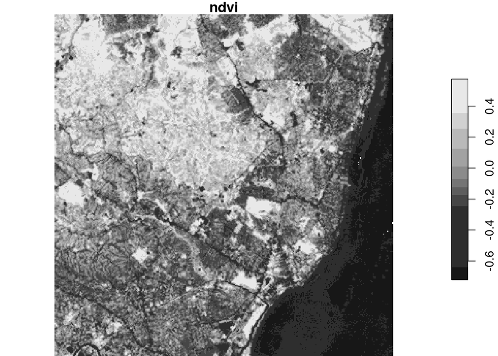

```
##    user  system elapsed
##   0.244   0.000   0.244
```

```r
system.time(plot(s2.ndvi))
```

### gdalcubes

Earth Observation Data Cubes from Satellite Image Collections - extension of the **stars** proxy mechansim and the **raster** out-of-memory approach: (https://github.com/appelmar/gdalcubes_R).

Processing collections of Earth observation images as on-demand multispectral, multitemporal data cubes. Users define cubes by spatiotemporal extent, resolution, and spatial reference system and let ‘gdalcubes’ automatically apply cropping, reprojection, and resampling using the ‘Geospatial Data Abstraction Library’ (‘GDAL’).

Implemented functions on data cubes include reduction over space and time, applying arithmetic expressions on pixel band values, moving window aggregates over time, filtering by space, time, bands, and predicates on pixel values, materializing data cubes as ‘netCDF’ files, and plotting. User-defined ‘R’ functions can be applied over chunks of data cubes. The package implements lazy evaluation and multithreading.

## Exercise + review

1. Start R, install package **stars** (if not already present), and load it

```r
library(stars)
```

2. load the Landsat image test set, as above

```r
tif <- system.file("tif/L7_ETMs.tif", package = "stars")
x <- read_stars(tif)
```

```r
str(x)
```

```
## List of 1
##  $ L7_ETMs.tif: num [1:349, 1:352, 1:6] 69 69 63 60 61 61 62 60 64 63 ...
##  - attr(*, "dimensions")=List of 3
##   ..$ x   :List of 7
##   .. ..$ from  : num 1
##   .. ..$ to    : num 349
##   .. ..$ offset: num 288776
##   .. ..$ delta : num 28.5
##   .. ..$ refsys: chr "+proj=utm +zone=25 +south +ellps=GRS80 +towgs84=0,0,0,0,0,0,0 +units=m +no_defs"
##   .. ..$ point : logi FALSE
##   .. ..$ values: NULL
##   .. ..- attr(*, "class")= chr "dimension"
##   ..$ y   :List of 7
##   .. ..$ from  : num 1
##   .. ..$ to    : num 352
##   .. ..$ offset: num 9120761
##   .. ..$ delta : num -28.5
##   .. ..$ refsys: chr "+proj=utm +zone=25 +south +ellps=GRS80 +towgs84=0,0,0,0,0,0,0 +units=m +no_defs"
##   .. ..$ point : logi FALSE
##   .. ..$ values: NULL
##   .. ..- attr(*, "class")= chr "dimension"
##   ..$ band:List of 7
##   .. ..$ from  : num 1
##   .. ..$ to    : Named int 6
##   .. .. ..- attr(*, "names")= chr "band"
##   .. ..$ offset: num NA
##   .. ..$ delta : num NA
##   .. ..$ refsys: chr NA
##   .. ..$ point : logi NA
##   .. ..$ values: NULL
##   .. ..- attr(*, "class")= chr "dimension"
##   ..- attr(*, "raster")=List of 3
##   .. ..$ affine     : num [1:2] 0 0
##   .. ..$ dimensions : chr [1:2] "x" "y"
##   .. ..$ curvilinear: logi FALSE
##   .. ..- attr(*, "class")= chr "stars_raster"
##   ..- attr(*, "class")= chr "dimensions"
##  - attr(*, "class")= chr "stars"
```

3. Create an RGB composite plot using argument `rgb = c(3,2,1)` for RGB, and `rgb = c(4,3,2)` for false color.

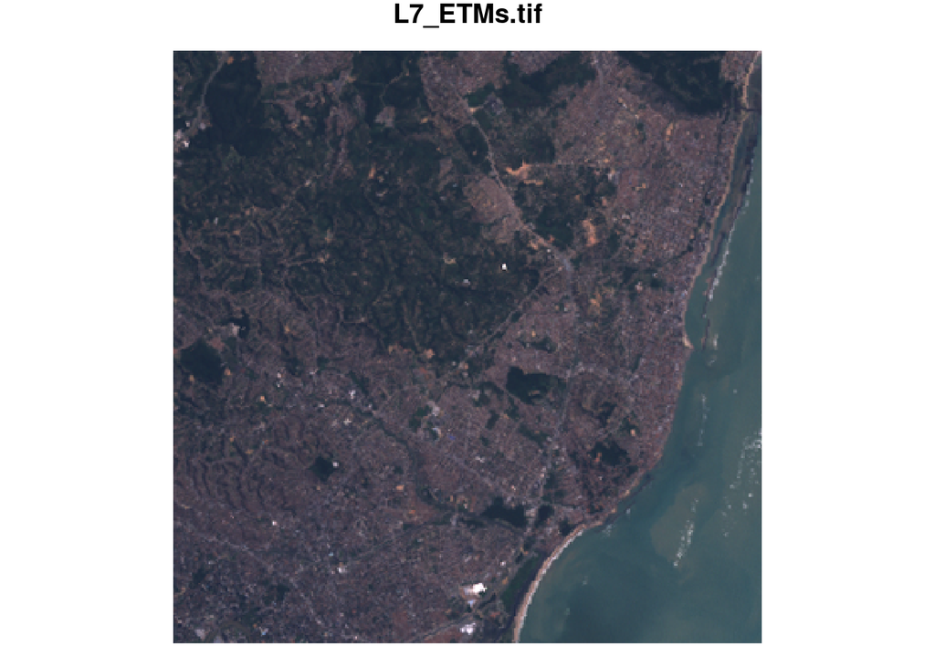

```r
plot(x, rgb = c(3, 2, 1))
```

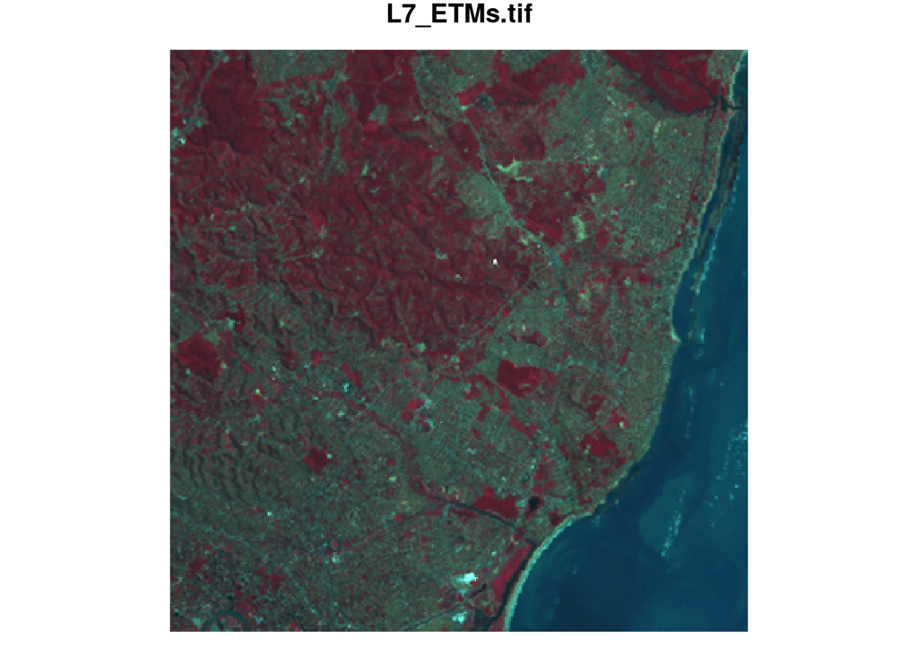

```r
plot(x, rgb = c(4, 3, 2))
```

4. Use `x6 <- split(x, "band")` to create a 2-dimensional raster with 6 attributes

```r
(x6 <- split(x, "band"))
```

```
## stars object with 2 dimensions and 6 attributes
## attribute(s):
##       X1               X2               X3               X4
##  Min.   : 47.00   Min.   : 32.00   Min.   : 21.00   Min.   :  9.00
##  1st Qu.: 67.00   1st Qu.: 55.00   1st Qu.: 49.00   1st Qu.: 52.00
##  Median : 78.00   Median : 66.00   Median : 63.00   Median : 63.00
##  Mean   : 79.15   Mean   : 67.57   Mean   : 64.36   Mean   : 59.24
##  3rd Qu.: 89.00   3rd Qu.: 79.00   3rd Qu.: 77.00   3rd Qu.: 75.00
##  Max.   :255.00   Max.   :255.00   Max.   :255.00   Max.   :255.00
##       X5               X6
##  Min.   :  1.00   Min.   :  1.00
##  1st Qu.: 63.00   1st Qu.: 32.00
##  Median : 89.00   Median : 60.00
##  Mean   : 83.18   Mean   : 59.98
##  3rd Qu.:112.00   3rd Qu.: 88.00
##  Max.   :255.00   Max.   :255.00
## dimension(s):
##   from  to  offset delta                       refsys point values
## x    1 349  288776  28.5 +proj=utm +zone=25 +south... FALSE   NULL [x]
## y    1 352 9120761 -28.5 +proj=utm +zone=25 +south... FALSE   NULL [y]
```

5. Plot `x6`. What has changed?

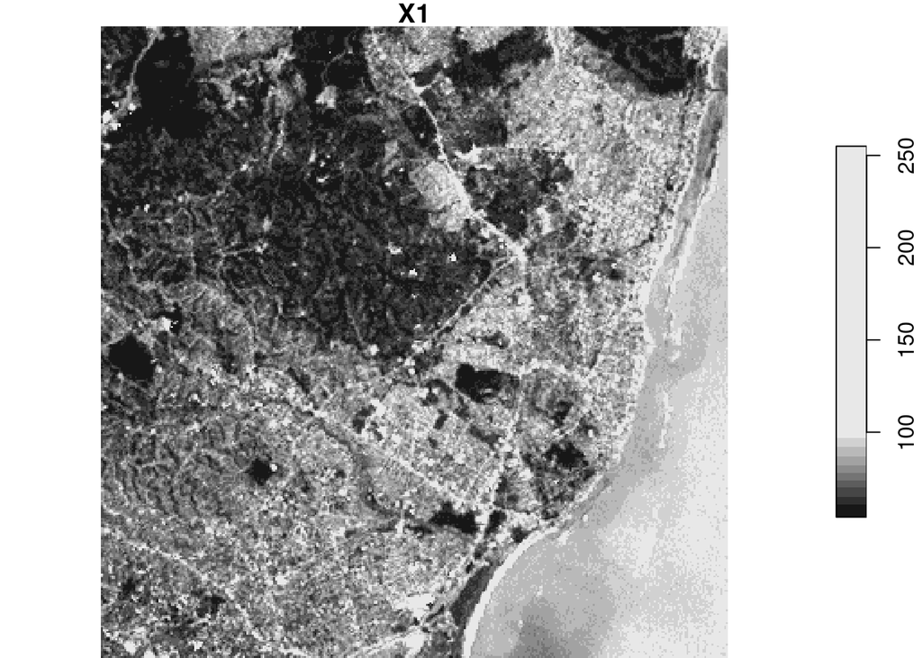

```r
plot(x6)
```

```r
str(x6)
```

```
## List of 6
##  $ X1: num [1:349, 1:352] 69 69 63 60 61 61 62 60 64 63 ...
##  $ X2: num [1:349, 1:352] 56 57 52 45 52 50 51 51 51 52 ...
##  $ X3: num [1:349, 1:352] 46 49 45 35 44 37 41 37 39 49 ...
##  $ X4: num [1:349, 1:352] 79 75 66 66 76 78 76 78 68 70 ...
##  $ X5: num [1:349, 1:352] 86 88 75 69 92 74 79 80 67 84 ...
##  $ X6: num [1:349, 1:352] 46 49 41 38 60 38 43 38 32 53 ...
##  - attr(*, "dimensions")=List of 2
##   ..$ x:List of 7
##   .. ..$ from  : num 1
##   .. ..$ to    : num 349
##   .. ..$ offset: num 288776
##   .. ..$ delta : num 28.5
##   .. ..$ refsys: chr "+proj=utm +zone=25 +south +ellps=GRS80 +towgs84=0,0,0,0,0,0,0 +units=m +no_defs"
##   .. ..$ point : logi FALSE
##   .. ..$ values: NULL
##   .. ..- attr(*, "class")= chr "dimension"
##   ..$ y:List of 7
##   .. ..$ from  : num 1
##   .. ..$ to    : num 352
##   .. ..$ offset: num 9120761
##   .. ..$ delta : num -28.5
##   .. ..$ refsys: chr "+proj=utm +zone=25 +south +ellps=GRS80 +towgs84=0,0,0,0,0,0,0 +units=m +no_defs"
##   .. ..$ point : logi FALSE
##   .. ..$ values: NULL
##   .. ..- attr(*, "class")= chr "dimension"
##   ..- attr(*, "raster")=List of 3
##   .. ..$ affine     : num [1:2] 0 0
##   .. ..$ dimensions : chr [1:2] "x" "y"
##   .. ..$ curvilinear: logi FALSE
##   .. ..- attr(*, "class")= chr "stars_raster"
##   ..- attr(*, "class")= chr "dimensions"
##  - attr(*, "class")= chr "stars"
```

6. Compute the mean of all six bands by adding all six attributes and dividing by 6, and assigning the resulting matrix as a new attribute in `x6`

```r
x6$mean <- (x6[[1]] + x6[[2]] + x6[[3]] + x6[[4]] + x6[[5]] + x6[[6]])/6
```

7. As an alternative, compute the mean of all six bands by applying function `mean` over the `x` and `y` dimensions (essentially reducing “band”), by using `st_apply`; compare the results of the two approaches

```r
xm <- st_apply(x, c("x", "y"), mean)
all.equal(xm[[1]], x6$mean)
```

```
## [1] TRUE
```

```r
str(xm)
```

```
## List of 1
##  $ mean: num [1:349, 1:352] 63.7 64.5 57 52.2 64.2 ...
##  - attr(*, "dimensions")=List of 2
##   ..$ x:List of 7
##   .. ..$ from  : num 1
##   .. ..$ to    : num 349
##   .. ..$ offset: num 288776
##   .. ..$ delta : num 28.5
##   .. ..$ refsys: chr "+proj=utm +zone=25 +south +ellps=GRS80 +towgs84=0,0,0,0,0,0,0 +units=m +no_defs"
##   .. ..$ point : logi FALSE
##   .. ..$ values: NULL
##   .. ..- attr(*, "class")= chr "dimension"
##   ..$ y:List of 7
##   .. ..$ from  : num 1
##   .. ..$ to    : num 352
##   .. ..$ offset: num 9120761
##   .. ..$ delta : num -28.5
##   .. ..$ refsys: chr "+proj=utm +zone=25 +south +ellps=GRS80 +towgs84=0,0,0,0,0,0,0 +units=m +no_defs"
##   .. ..$ point : logi FALSE
##   .. ..$ values: NULL
##   .. ..- attr(*, "class")= chr "dimension"
##   ..- attr(*, "raster")=List of 3
##   .. ..$ affine     : num [1:2] 0 0
##   .. ..$ dimensions : chr [1:2] "x" "y"
##   .. ..$ curvilinear: logi FALSE
##   .. ..- attr(*, "class")= chr "stars_raster"
##   ..- attr(*, "class")= chr "dimensions"
##  - attr(*, "class")= chr "stars"
```

Bivand, Roger S., Edzer Pebesma, and Virgilio Gomez-Rubio. 2013. *Applied Spatial Data Analysis with R, Second Edition*. Springer, NY. http://www.asdar-book.org/.

Lapa, Tiago, Ricardo Ximenes, Nilza Nunes Silva, Wayner Souza, Maria de Fátima Militão Albuquerque, and Gisele Campozana. 2001. “Vigilância da hanseníase em Olinda, Brasil, utilizando técnicas de análise espacial.” *Cadernos de Saúde Pública* 17 (October). scielo: 1153–62. https://doi.org/10.1590/S0102-311X2001000500016.

Lovelace, Robin, Jakub Nowosad, and Jannes Muenchow. 2019. *Geocomputation with R*. Boca Raton, FL: Chapman and Hall/CRC.

Pebesma, Edzer, and Roger S. Bivand. n.d. *Spatial Data Science; Uses Cases in R*. CRC. https://r-spatial.org/book/.